# My visual data story - Project 4

STATS 220 Semester One, 2026

Mai Pham - mpha134

2026-04-29

## Plot 1:

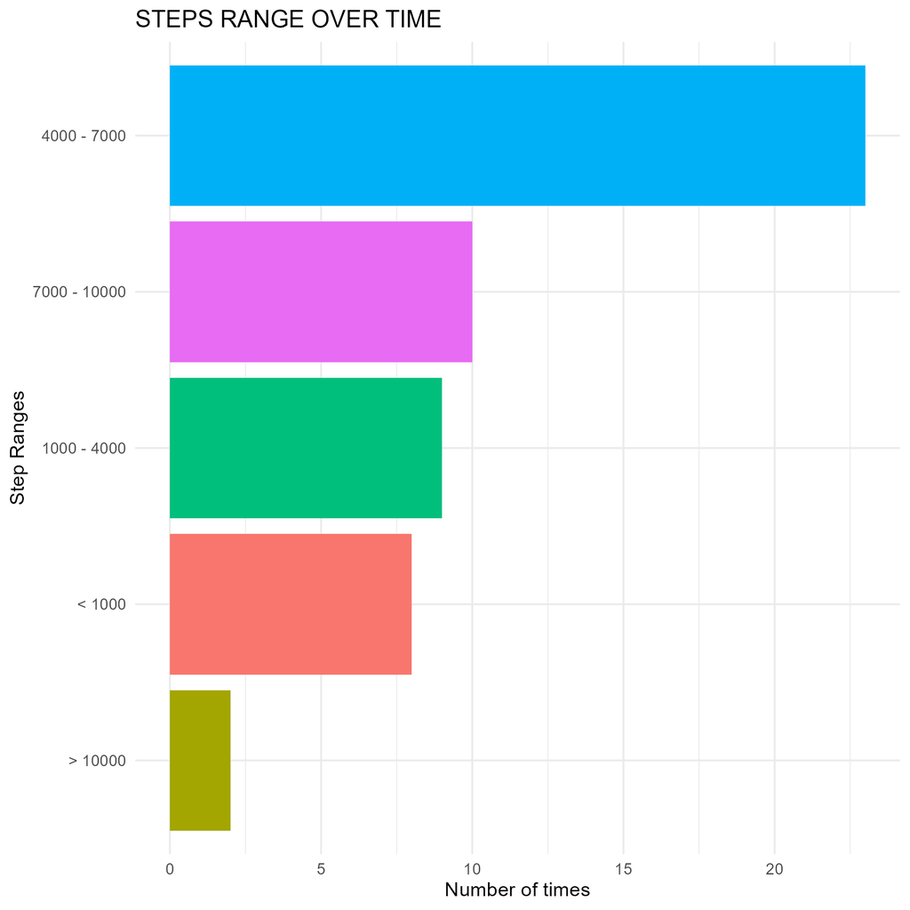

Plot 1 (Steps range over time) shows the interaction between differennt ranges of step and their number of times repeated in the period of 52 days collecting data. The most and least frequent step range is 4000 - 7000 and more than 10000 respectively

Overall, I mostly walked 4000 - 7000 steps per day that there were 23 days of the range. There was only 2 day that I walk more than 10000 steps.

## Plot 2:

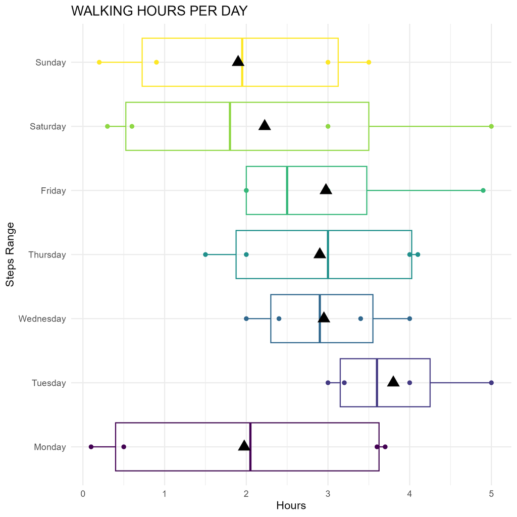

Plot 2 (Walking hours per day) shows number of walking hours for each day in the period of 28 days collecting data for the project 4 which were the new data. This also shows the interquatile range, median and mean of hours of each day.

On average, I walked 1.98, 3.8, 2.95, 2.9, 2.98, 2.22, 1.9 hours on Monday, Tuesday, Wednesday, Thursday, Friday, Saturday, Sunday over 4 weeks from 31/03/2026 to 29/04/2026. The boxplot showed that the there are variety of hours I walked in a day which was not consistent. Based on the median, it showed that I tended to walk for longer hours on weekdays than weekend.

## Plot 3:

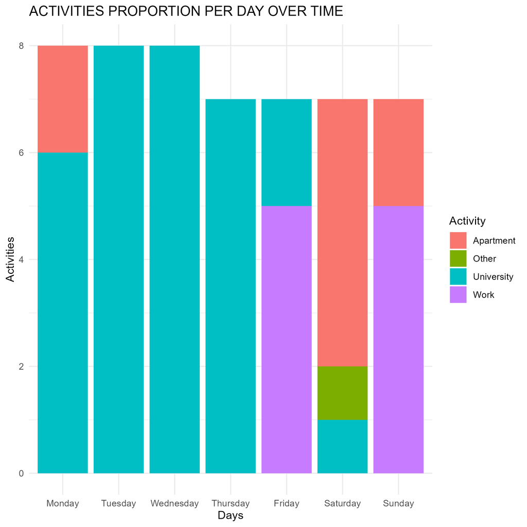

Plot 3 (Activities proportion per day over time) shows proportion of each activity for each day column. Each activity has a different colour, so each day column has more than 1 colour if there were more than 1 activity were done on that day in different week.

Overall, the activity of going to University was the activity contributing the most to the my step ranges from Monday to Thursday. I have a part-time job on Friday and Sunday, so it contributed the most to my step range. Lastly, Saturday is weekend and I do not have work on that day, I stay at my department most of the time, so staying in my apartment is the activity contributing the most to my step range.